# Full downstream mouse-spleen reproduction: compiled C++ AutoK and K=11 sensitivity

CellCharterR contributors

2026-10-16 12:52 UTC

> **Scope and provenance.** This preserved report starts from the fixed published trVAE representation and reproduces the downstream graph, aggregation, AutoK/GMM, enrichment, and proximity stages. It is not a claim of end-to-end representation equivalence. Every domain figure and downstream result in this report was generated from the completed compiled C++ CPU run. R Torch/CUDA remains available as an experimental alternative.

> **Static report.** The installed HTML is self-contained scientific evidence. Its source is archival and expects the preserved result directory named in `params$result_dir`; it is not intended to rerun a full-data analysis during package installation.

This is the second CellCharterR tutorial and the complete scientific reproduction report. New users should first read the [beginner workflow](https://cperalta-viteri.github.io/CellCharterR/docs/CellCharterR-beginner-workflow.html). The next tutorial demonstrates [additional downstream analyses](https://cperalta-viteri.github.io/CellCharterR/docs/CellCharterR-differential-neighborhood-networks.html) from the preserved C++ K=10 result.

# 1 Scope and artifact roles

This report consumes the completed compiled-C++ outputs. Earlier provisional outputs are not used here. The primary result is K=10, selected independently by the compiled C++ AutoK run over the predeclared range K=2 through K=20. The K=11 panel is a separate compiled C++ sensitivity fit corresponding to the tutorial’s requested resolution and seed 12345. The C++ and Python implementations use different initialization and random-number streams, so this does not claim seed-identical fitted parameters. Published H5AD `cluster_cellcharter` labels are not plotted as either R result.

```r
role_table <- do.call(rbind, lapply(manifest$roles, function(x) data.frame(
  role_id = x$role_id,
  k = x$k,
  seed = if (is.na(x$seed)) "NA (not an R fit)" else as.character(x$seed),
  stringsAsFactors = FALSE
)))
knitr::kable(role_table, caption = "Non-interchangeable analysis roles")
```

Non-interchangeable analysis roles

|  | role_id | k | seed |
| --- | --- | --- | --- |
| Primary | r_cpp_autok_primary | 10 | 0 |
| TutorialK11 | r_cpp_tutorial_k11_sensitivity | 11 | 12345 |

```r
provenance <- data.frame(
  field = c(
    "Backend", "CellCharter reference", "Reference commit", "Analysis graph",
    "Spots", "Libraries", "Displayed slides", "AutoK elapsed"
  ),
  value = c(
    manifest$backend, manifest$reference_version, manifest$reference_commit,
    manifest$graph_source, format(manifest$spots, big.mark = ","),
    length(manifest$samples), paste(manifest$displayed_samples, collapse = ", "),
    sprintf("%.1f minutes", manifest$autok$elapsed_seconds / 60)
  )
)
knitr::kable(provenance, caption = "Compact provenance for the preserved analysis")
```

Compact provenance for the preserved analysis

| field | value |
| --- | --- |
| Backend | compiled-cpp-double |
| CellCharter reference | CellCharter 0.2.0 |
| Reference commit | 2a8fdde8213e32e5a00f1f9571bffd3dbb825a79 |
| Analysis graph | R-native Qhull with pinned CellCharter 0.2.0 global cutoff |
| Spots | 707,474 |
| Libraries | 9 |
| Displayed slides | BALBc-1, MRL-4 |
| AutoK elapsed | 38.3 minutes |

Only BALBc-1 and early MRL-4 are displayed in maps. Enrichment and proximity statistics use all nine libraries. The full `cell_type` annotation is used for the log2 observed/expected dot plot with `size_threshold=0.58`, `color_threshold=0.58`, and the CellCharter v0.2.0 default clustered labels.

## 1.1 Full mouse-spleen before/after benchmark

```r
format_duration <- function(seconds) {
  hours <- floor(seconds / 3600)
  minutes <- floor((seconds %% 3600) / 60)
  secs <- round(seconds %% 60)
  sprintf("%dh %02dm %02ds", hours, minutes, secs)
}

benchmark_table <- data.frame(
  implementation = c(
    manifest$benchmark$legacy$backend,
    manifest$benchmark$cpp$backend
  ),
  spatial_spots = format(manifest$benchmark$spots, big.mark = ","),
  features = manifest$benchmark$features,
  AutoK_rounds = manifest$benchmark$rounds,
  GMM_fits = manifest$benchmark$fits,
  observed_wall_time = c(
    paste0(">= ", format_duration(
      manifest$benchmark$legacy$elapsed_lower_bound_seconds
    )),
    format_duration(manifest$benchmark$cpp$elapsed_seconds)
  ),
  execution = c(
    paste0(manifest$benchmark$legacy$device, "; sequential K fits"),
    paste0(
      manifest$benchmark$cpp$workers, " workers x ",
      manifest$benchmark$cpp$threads_per_fit, " threads"
    )
  ),
  check.names = FALSE
)
knitr::kable(
  benchmark_table,
  caption = "Observed timing for the same first five AutoK rounds (K=1 through K=21)"
)
```

Observed timing for the same first five AutoK rounds (K=1 through K=21)

| implementation | spatial_spots | features | AutoK_rounds | GMM_fits | observed_wall_time | execution |
| --- | --- | --- | --- | --- | --- | --- |
| R torch CUDA (sequential K fits) | 707,474 | 40 | 5 | 105 | >= 49h 47m 25s | NVIDIA RTX A4000; sequential K fits |
| compiled C++ CPU (concurrent K fits) | 707,474 | 40 | 5 | 105 | 0h 38m 20s | 8 workers x 4 threads |

For 707,474 spatial spots and 40 aggregated features, the compiled C++ run completed the same 105-fit, five-round comparison window at least 77.9 times faster. The legacy time is a conservative lower bound reconstructed from completed checkpoint timestamps, whereas the C++ duration was recorded by the runner. This is an observed workflow comparison, not a controlled microbenchmark: the backends use different initializers and numerical engines. The comparison is therefore evidence of the practical wall-time improvement, not a claim that both optimizers produce identical fitted parameters.

# 2 From input SPE to saved results

The full mouse-spleen analysis is deliberately not rerun while this report is rendered. The code below shows the public stages used to create the graph, in-memory neighborhood representation, AutoK fit, selected domains, and downstream statistics. The evaluated sections that follow load the corresponding precomputed artifacts and display their outputs.

```r
full_spe <- readRDS("results/CellCharterR_mouse_spleen_v2/representation/codex_sce.rds")

full_spe <- cellcharter_graph(
  full_spe,
  spatial = "spatial",
  sample_col = "sample",
  graph_name = "cellcharter_graph",
  percentile = 99
)

full_spe <- cellcharter_aggregate(
  full_spe,
  representation = "X_trVAE",
  graph_name = "cellcharter_graph",
  sample_col = "sample",
  output = "X_cellcharter",
  n_layers = 3L
)

saveRDS(
  full_spe,
  "results/CellCharterR_mouse_spleen_v2/aggregation/spe_after_aggregation.rds",
  compress = FALSE
)

full_spe <- cellcharter_cluster(
  full_spe,
  representation = "X_cellcharter",
  candidate_k = 2:20,
  checkpoint_dir = "results/CellCharterR_mouse_spleen_cpp_v1/unused-no-checkpoints",
  domain_col = "cellcharter_domain",
  max_runs = 10L,
  convergence_tol = 0.01,
  seed = 0L,
  backend = "cpp",
  workers = 8L,
  threads_per_fit = 4L,
  checkpoint_mode = "none",
  fit_args = list(
    max_iter = 100L,
    tolerance = 0.001,
    covariance_regularization = 1e-6
  ),
  resume = FALSE
)

full_spe <- cellcharter_enrichment(
  full_spe,
  group_col = "cell_type",
  domain_col = "cellcharter_domain"
)
full_spe <- cellcharter_nhood_enrichment(
  full_spe,
  graph_name = "cellcharter_graph",
  domain_col = "cellcharter_domain"
)
full_spe <- cellcharter_diff_nhood_enrichment(
  full_spe,
  graph_name = "cellcharter_graph",
  domain_col = "cellcharter_domain",
  condition_col = "condition",
  sample_col = "sample",
  condition_groups = c("BALBc", "MRL"),
  n_perms = 100L,
  seed = 0L,
  permutation_mode = "cellcharter_v0.2.0"
)

saveRDS(
  full_spe,
  "results/CellCharterR_mouse_spleen_v2/downstream/codex_spe_complete.rds"
)
```

## 2.1 Optional resumable compiled C++ run

The measured 38-minute run above used `checkpoint_mode = "none"` to avoid all fit-checkpoint I/O. If interruption recovery is more important, use a new directory and `checkpoint_mode = "round"`; repeat this exact call with `resume = TRUE` after an interruption.

```r
full_spe <- readRDS(
  "results/CellCharterR_mouse_spleen_v2/aggregation/spe_after_aggregation.rds"
)

full_spe <- cellcharter_cluster(
  full_spe,
  representation = "X_cellcharter",
  candidate_k = 2:20,
  checkpoint_dir = "results/CellCharterR_mouse_spleen_cpp_resumable/autok",
  domain_col = "cellcharter_domain",
  max_runs = 10L,
  convergence_tol = 0.01,
  seed = 0L,
  backend = "cpp",
  workers = 8L,
  threads_per_fit = 4L,
  checkpoint_mode = "round",
  fit_args = list(
    max_iter = 100L, tolerance = 0.001,
    covariance_regularization = 1e-6
  ),
  resume = TRUE
)
```

The resume call is deliberately identical to the original fit call. Changing the backend, seed, candidate range, or numerical settings creates a different fit contract and must use a new checkpoint directory.

## 2.2 Optional compact wrapper

For a compact dataset, `cellcharter_workflow()` composes the same stages. It is shown for completeness, but the staged version above is preferable for the full dataset because it exposes each durable checkpoint. If aggregation exceeds available RAM, add `filepath = ...` and retain that optional HDF5 file with the SPE.

```r
full_spe <- cellcharter_workflow(
  full_spe,
  group_col = "cell_type",
  candidate_k = 2:20,
  checkpoint_dir = "results/CellCharterR_mouse_spleen_cpp_v1/unused-no-checkpoints",
  representation = "X_trVAE",
  sample_col = "sample",
  condition_col = "condition",
  aggregated = "X_cellcharter",
  domain_col = "cellcharter_domain",
  n_layers = 3L,
  condition_groups = c("BALBc", "MRL"),
  n_perms = 100L,
  seed = 0L,
  autok_args = list(
    backend = "cpp",
    workers = 8L,
    threads_per_fit = 4L,
    checkpoint_mode = "none",
    fit_args = list(
      max_iter = 100L, tolerance = 0.001,
      covariance_regularization = 1e-6
    )
  )
)
```

# 3 AutoK stability and K selection

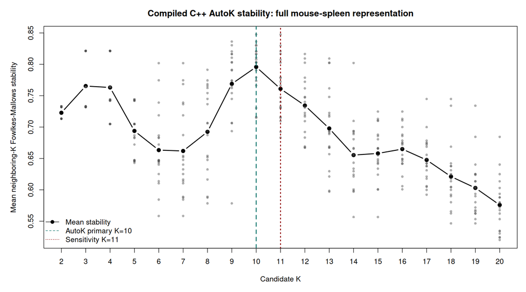

Compiled C++ neighboring-K Fowlkes–Mallows stability for the full mouse-spleen analysis. K=10 is the independently selected primary resolution; K=11 is highlighted as the tutorial-matched sensitivity resolution, while other local peaks remain visible.

```r
knitr::include_graphics(manifest$autok_stability_plot)
```

# 4 Independently R-selected AutoK primary analysis

```r
primary_k <- manifest$primary_k
primary_paths <- manifest$artifacts$Primary
primary_map <- readRDS(primary_paths[["map_input"]])
primary_enrichment <- readRDS(primary_paths[["enrichment"]])
primary_nhood <- readRDS(primary_paths[["nhood"]])
primary_mrl_balbc <- readRDS(primary_paths[["differential_mrl_balbc"]])
primary_balbc_mrl <- readRDS(primary_paths[["differential_balbc_mrl"]])
```

## 4.1 BALBc-1 and early MRL-4 domains

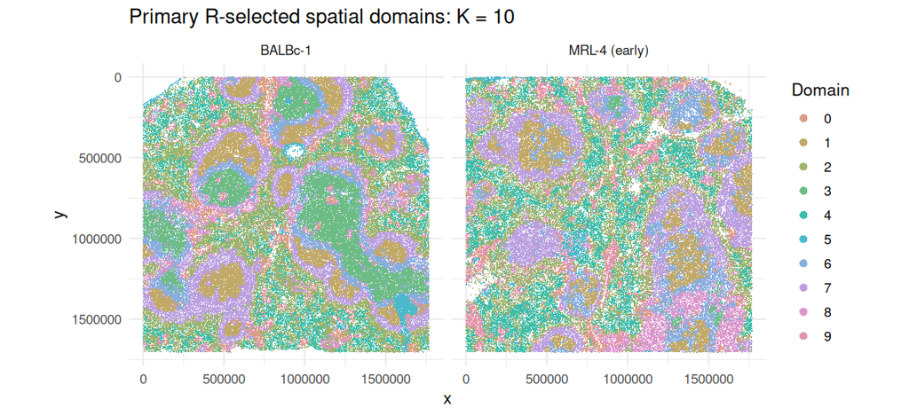

Compiled C++ AutoK-primary K=10 spatial domains in the BALBc-1 and early MRL-4 slides.

```r
primary_spe <- map_to_spe(primary_map, primary_k)
ggspavis::plotCoords(
  primary_spe,
  annotate = "domain",
  sample_id = "sample_id",
  in_tissue = NULL,
  point_size = 0.1,
  pal = grDevices::hcl.colors(primary_k, "Dynamic")
) +
  ggplot2::labs(
    colour = "Domain",
    title = paste0("Primary R-selected spatial domains: K = ", primary_k)
  ) +
  ggplot2::theme_minimal(base_size = 16)
```

```r
knitr::kable(
  as.data.frame(table(sample = primary_map$sample, domain = primary_map$domain)),
  caption = "Accessible spot counts underlying the primary domain maps"
)
```

## 4.2 Cluster ~ full cell type dot plot (log2 observed/expected)

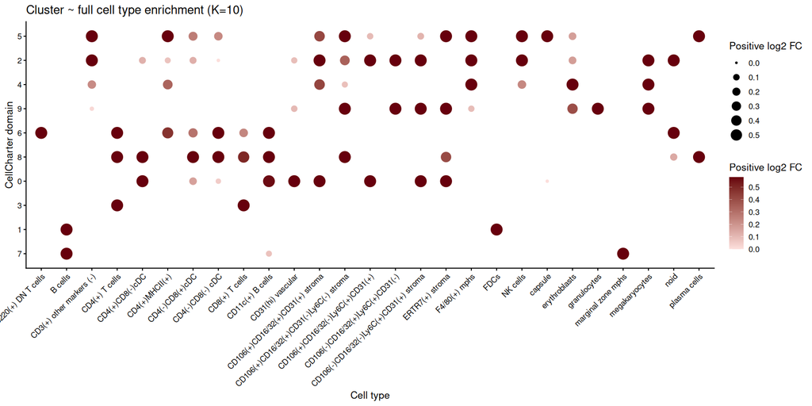

Positive cell-type enrichment in the compiled C++ primary K=10 domains. Darker and larger red points indicate stronger positive log2 fold change.

```r
graphics::par(mar = c(18, 6, 3, 1))
CellCharterR::cellcharter_plot_enrichment(
  primary_enrichment,
  title = paste0("Cluster ~ full cell type enrichment (K=", primary_k, ")")
)
```

```r
primary_enrichment_table <- as.data.frame(
  as.table(primary_enrichment$enrichment), stringsAsFactors = FALSE
)
names(primary_enrichment_table) <- c("cell_type", "domain", "log2_enrichment")
knitr::kable(primary_enrichment_table,
             caption = "Values underlying the primary enrichment dot plot")
```

## 4.3 BALBc and MRL neighborhood enrichment

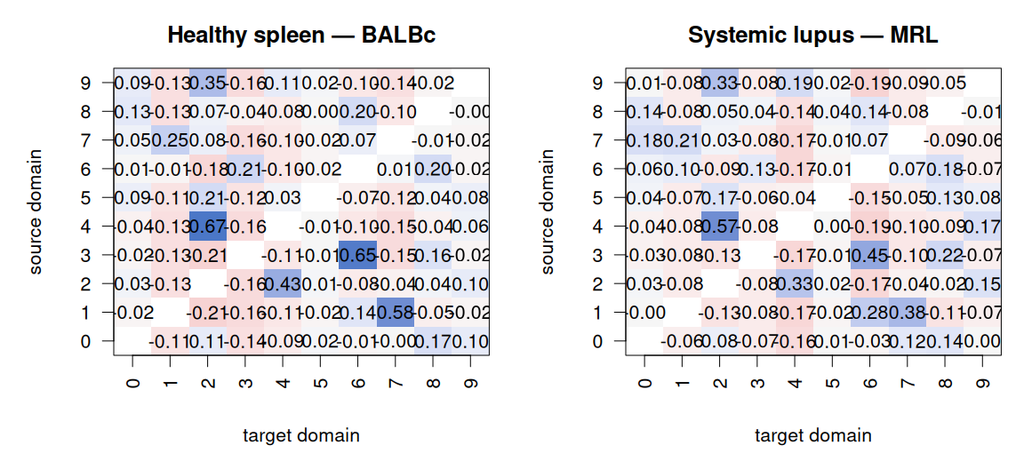

Directed observed-minus-expected neighborhood enrichment for BALBc and MRL at the compiled C++ primary K=10 resolution.

```r
graphics::par(mfrow = c(1, 2), mar = c(5, 5, 3, 1))
plot_heatmap(
  primary_nhood$BALBc$enrichment, "Healthy spleen — BALBc",
  limits = c(-1, 1), annotate = TRUE
)
plot_heatmap(
  primary_nhood$MRL$enrichment, "Systemic lupus — MRL",
  limits = c(-1, 1), annotate = TRUE
)
```

```r
primary_nhood_table <- rbind(
  matrix_long(primary_nhood$BALBc$enrichment, "enrichment", "BALBc"),
  matrix_long(primary_nhood$MRL$enrichment, "enrichment", "MRL")
)
knitr::kable(primary_nhood_table,
             caption = "Values underlying the primary neighborhood heatmaps")
```

## 4.4 Differential neighborhood enrichment in both display directions

Both panels reuse one sample-level permutation result (`n_perms=100`). A star marks directional empirical `p <= 0.05`; reversing the display negates only the effect and reuses the same permutation counts and p-values.

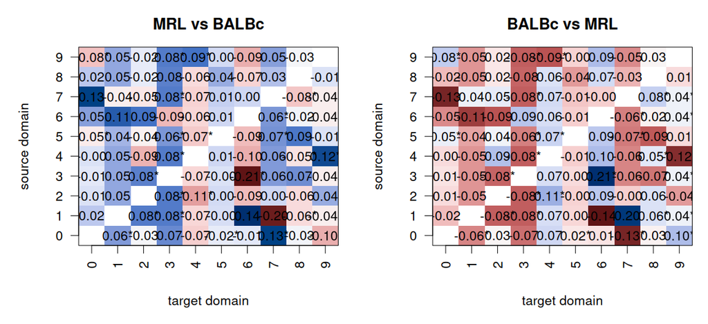

Compiled C++ primary K=10 differential directed neighborhood enrichment in both MRL-minus-BALBc and BALBc-minus-MRL display directions.

```r
graphics::par(mfrow = c(1, 2), mar = c(5, 5, 3, 1))
plot_heatmap(
  primary_mrl_balbc$effect, "MRL vs BALBc", annotate = TRUE,
  pvalue = primary_mrl_balbc$pvalue, significance = 0.05
)
plot_heatmap(
  primary_balbc_mrl$effect, "BALBc vs MRL", annotate = TRUE,
  pvalue = primary_balbc_mrl$pvalue, significance = 0.05
)
```

```r
primary_diff_table <- matrix_long(primary_mrl_balbc$effect, "MRL_minus_BALBc")
primary_diff_table$empirical_pvalue <- as.vector(primary_mrl_balbc$pvalue)
knitr::kable(primary_diff_table,
             caption = "Values underlying the primary differential heatmaps")
```

# 5 Standalone tutorial-matched K=11 sensitivity analysis

The C++ K=11 sensitivity was one standalone fit, not an AutoK selection and not the published H5AD labels. These are the exact historical settings used to generate its preserved labels:

```r
full_spe <- cellcharter_cluster_fixed(
  full_spe,
  representation = "X_cellcharter",
  n_clusters = 11L,
  domain_col = "cellcharter_domain_k11_sensitivity",
  checkpoint_dir = "results/CellCharterR_mouse_spleen_v2/tutorial_k11_standalone",
  seed = 12345L,
  fit_args = list(
    max_iter = 100L,
    tolerance = 0.001,
    covariance_regularization = 1e-6,
    num_threads = 4L
  ),
  predict_args = list(),
  fit_fun = cpp_gmm_fit,
  predict_fun = cpp_gmm_predict,
  resume = TRUE
)
```

```r
k11_paths <- manifest$artifacts$TutorialK11
k11_map <- readRDS(k11_paths[["map_input"]])
k11_enrichment <- readRDS(k11_paths[["enrichment"]])
k11_nhood <- readRDS(k11_paths[["nhood"]])
k11_mrl_balbc <- readRDS(k11_paths[["differential_mrl_balbc"]])
k11_balbc_mrl <- readRDS(k11_paths[["differential_balbc_mrl"]])
```

## 5.1 BALBc-1 and early MRL-4 domains

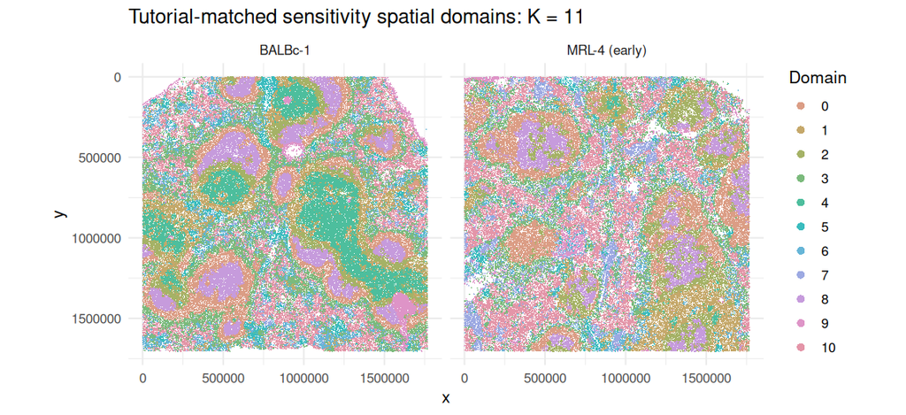

Tutorial-matched K=11 sensitivity domains in the BALBc-1 and early MRL-4 slides.

```r
k11_spe <- map_to_spe(k11_map, 11L)
ggspavis::plotCoords(
  k11_spe,
  annotate = "domain",
  sample_id = "sample_id",
  in_tissue = NULL,
  point_size = 0.1,
  pal = grDevices::hcl.colors(11L, "Dynamic")
) +
  ggplot2::labs(
    colour = "Domain",
    title = "Tutorial-matched sensitivity spatial domains: K = 11"
  ) +
  ggplot2::theme_minimal(base_size = 16)
```

```r
knitr::kable(
  as.data.frame(table(sample = k11_map$sample, domain = k11_map$domain)),
  caption = "Accessible spot counts underlying the K=11 domain maps"
)
```

## 5.2 Cluster ~ full cell type dot plot (log2 observed/expected)

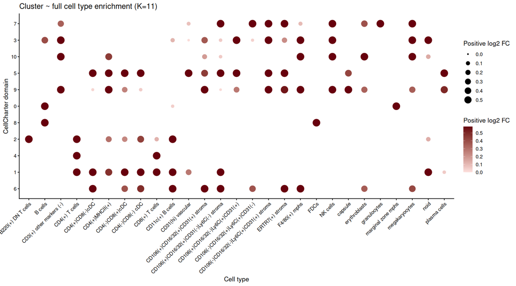

Positive cell-type enrichment in the tutorial-matched K=11 sensitivity domains. Darker and larger red points indicate stronger positive log2 fold change.

```r
graphics::par(mar = c(18, 6, 3, 1))
CellCharterR::cellcharter_plot_enrichment(
  k11_enrichment,
  title = "Cluster ~ full cell type enrichment (K=11)"
)
```

```r
k11_enrichment_table <- as.data.frame(
  as.table(k11_enrichment$enrichment), stringsAsFactors = FALSE
)
names(k11_enrichment_table) <- c("cell_type", "domain", "log2_enrichment")
knitr::kable(k11_enrichment_table,
             caption = "Values underlying the K=11 enrichment dot plot")
```

## 5.3 BALBc and MRL neighborhood enrichment

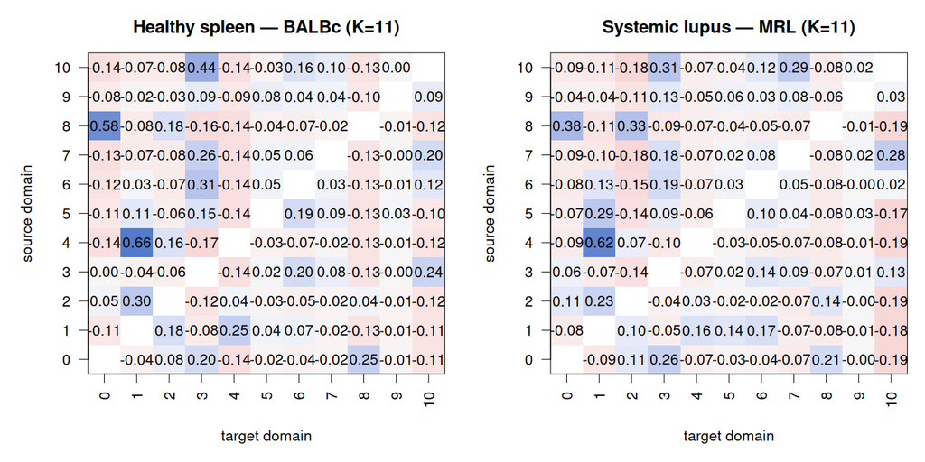

Directed observed-minus-expected neighborhood enrichment for BALBc and MRL at the K=11 sensitivity resolution.

```r
graphics::par(mfrow = c(1, 2), mar = c(5, 5, 3, 1))
plot_heatmap(
  k11_nhood$BALBc$enrichment, "Healthy spleen — BALBc (K=11)",
  limits = c(-1, 1), annotate = TRUE
)
plot_heatmap(
  k11_nhood$MRL$enrichment, "Systemic lupus — MRL (K=11)",
  limits = c(-1, 1), annotate = TRUE
)
```

```r
k11_nhood_table <- rbind(
  matrix_long(k11_nhood$BALBc$enrichment, "enrichment", "BALBc"),
  matrix_long(k11_nhood$MRL$enrichment, "enrichment", "MRL")
)
knitr::kable(k11_nhood_table,
             caption = "Values underlying the K=11 neighborhood heatmaps")
```

## 5.4 Differential neighborhood enrichment in both display directions

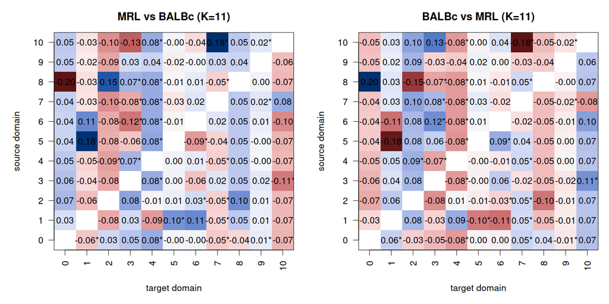

K=11 sensitivity differential directed neighborhood enrichment in both MRL-minus-BALBc and BALBc-minus-MRL display directions.

```r
graphics::par(mfrow = c(1, 2), mar = c(5, 5, 3, 1))
plot_heatmap(
  k11_mrl_balbc$effect, "MRL vs BALBc (K=11)", annotate = TRUE,
  pvalue = k11_mrl_balbc$pvalue, significance = 0.05
)
plot_heatmap(
  k11_balbc_mrl$effect, "BALBc vs MRL (K=11)", annotate = TRUE,
  pvalue = k11_balbc_mrl$pvalue, significance = 0.05
)
```

```r
k11_diff_table <- matrix_long(k11_mrl_balbc$effect, "MRL_minus_BALBc")
k11_diff_table$empirical_pvalue <- as.vector(k11_mrl_balbc$pvalue)
knitr::kable(k11_diff_table,
             caption = "Values underlying the K=11 differential heatmaps")
```

# 6 Interpretation boundary

The R-selected AutoK K remains the only primary result. K=11 is a separately fitted tutorial sensitivity analysis. The published H5AD labels remain a separate reference artifact. Representation-learning equivalence is not claimed because the supplied trVAE representation is treated as immutable input. Spatial panels use `ggspavis::plotCoords()` on `SpatialExperiment` objects with the exact saved coordinates and labels. Pixel-level equivalence to Squidpy’s plotting stack is not claimed.